# Gotta Train 'ML (em all)

## Pokemon- Weedle's Cave

### Motivation.

I'm pretty good at using R for genomics/bioinformatics (ie, code and data for a published paper where I [integrated -*omic* data to understand how two tomato species respond to elevated CO<sub>2</sub>](https://github.com/rodriguezmDNA/Gray_RodriguezMedina_CO2Supplemental)). I use a lot of R packages for data wrangling, processing, stats and viz on a daily basis, but I've almost always eluded Python, even though I have a good grasp of the language. When I found some Data Science challenges online and I took it upon myself to address them without using R.

Also, I recently started learning about machine learning for predicting outcomes using training data. It is something I haven't gotten to do yet, but what better way to learn than by doing?

**Don't panic.**

Data source:

Pokemon- Weedle's Cave data source and more info: https://www.kaggle.com/terminus7/pokemon-challenge/version/1

More info: https://www.kaggle.com/kanncaa1/data-sciencetutorial-for-beginners

```python
# Check version of Python
import sys
print (sys.version)
```

```
3.6.5 (default, Apr 25 2018, 14:26:36)
[GCC 4.2.1 Compatible Apple LLVM 9.0.0 (clang-900.0.39.2)]
```

```python
## Load libraries to read, wrangle and process data
import numpy as np # linear algebra
import pandas as pd # data processing, CSV file I/O
import matplotlib.pyplot as plt
import seaborn as sns  # visualization tool
```

```python
ls Data #cheating, this is command line. # But I know I put the data in the "data" folder...where else?
```

```
combats.csv* pokemon.csv* tests.csv*
```

```python
pokemonData = pd.read_csv('data/pokemon.csv')
```

Let's take a peek at the data with `.head()`:

|  | # | Name | Type 1 | Type 2 | HP | Attack | Defense | Sp. Atk | Sp. Def | Speed | Generation | Legendary |
| --- | --- | --- | --- | --- | --- | --- | --- | --- | --- | --- | --- | --- |
| 0 | 1 | Bulbasaur | Grass | Poison | 45 | 49 | 49 | 65 | 65 | 45 | 1 | False |
| 1 | 2 | Ivysaur | Grass | Poison | 60 | 62 | 63 | 80 | 80 | 60 | 1 | False |
| 2 | 3 | Venusaur | Grass | Poison | 80 | 82 | 83 | 100 | 100 | 80 | 1 | False |
| 3 | 4 | Mega Venusaur | Grass | Poison | 80 | 100 | 123 | 122 | 120 | 80 | 1 | False |
| 4 | 5 | Charmander | Fire | NaN | 39 | 52 | 43 | 60 | 50 | 65 | 1 | False |

We can also get a summary of the dataset using the `.info()` method:

```python
pokemonData.info()
```

```
<class 'pandas.core.frame.DataFrame'>
RangeIndex: 800 entries, 0 to 799
Data columns (total 12 columns):
#             800 non-null int64
Name          799 non-null object
Type 1        800 non-null object
Type 2        414 non-null object
HP            800 non-null int64
Attack        800 non-null int64
Defense       800 non-null int64
Sp. Atk       800 non-null int64
Sp. Def       800 non-null int64
Speed         800 non-null int64
Generation    800 non-null int64
Legendary     800 non-null bool
dtypes: bool(1), int64(8), object(3)
memory usage: 69.6+ KB
```

We have data for 800 different pokemon. Each row corresponds to a different *pokemon species*(?) -I'm not an evo-devo-poke-taxonomists,*dont @ me!*-.

We have *phenotypic data* for each pokemon: Two different classifications (types 1 and 2), their health points, attack, and defense points, plus some other info.

### Cleaning data

Before we even begin, let's check if we have any missing data.

running `pd.isna(pokemonData).sum()` will tell us how many missing values (`NA`) are there per column:

```python
pd.isna(pokemonData).sum()
```

```
#               0
Name            1
Type 1          0
Type 2        386
HP              0
Attack          0
Defense         0
Sp. Atk         0
Sp. Def         0
Speed           0
Generation      0
Legendary       0
dtype: int64
```

It appears that a name is missing for one Pokemon. Also, for 386 of them we don't have Type 2 information. We can work with that, since Pokemon can have dual or single type <sup>[ref](https://bulbapedia.bulbagarden.net/wiki/Type#Type_chart)</sup>

Missing values in the rest of the data (attack, health points) would be a problem.

If we wanted to filter out the pokemon with no name or type we would use:

`pokemonData_filter = pokemonData[pokemonData['Name'].notnull()]`

or

`pokemonData_filter = pokemonData[pokemonData['Type 2'].notnull()]`

For example, removing the Pokemon without a name would give us a table of 799 rows with the same number of columns (12):

(799, 12)

### The case of the missing Pokemon

Who is the missing Pokemon?

|  | # | Name | Type 1 | Type 2 | HP | Attack | Defense | Sp. Atk | Sp. Def | Speed | Generation | Legendary |
| --- | --- | --- | --- | --- | --- | --- | --- | --- | --- | --- | --- | --- |
| 62 | 63 | NaN | Fighting | NaN | 65 | 105 | 60 | 60 | 70 | 95 | 1 | False |

In case you were wondering, it is Primeape (don't ask me how I found out). I would say that a huge part of data science is about telling a story, not only spitting out numbers that might look meaningless.

Data science is very much about doing a bit of research, being invested in the data and appreciate how it was generated. What it might mean, what can we learn from it.

Let's take a moment and fill in the blanks where we can:

```python
pokemonData["Name"][62] = "Primeape"
```

And it works:

Primeape

# EDA

> "*Data! data! data!* " he cried impatiently. "I can't make bricks without clay."

> Arthur Conan Doyle (The Adventure of the Copper Beeches)

As a manner to start looking at the data we could look at how the relationships between different characteristics:

|  | # | HP | Attack | Defense | Sp. Atk | Sp. Def | Speed | Generation | Legendary |
| --- | --- | --- | --- | --- | --- | --- | --- | --- | --- |
| # | 1.000000 | 0.097712 | 0.102664 | 0.094691 | 0.089199 | 0.085596 | 0.012181 | 0.983428 | 0.154336 |
| HP | 0.097712 | 1.000000 | 0.422386 | 0.239622 | 0.362380 | 0.378718 | 0.175952 | 0.058683 | 0.273620 |
| Attack | 0.102664 | 0.422386 | 1.000000 | 0.438687 | 0.396362 | 0.263990 | 0.381240 | 0.051451 | 0.345408 |
| Defense | 0.094691 | 0.239622 | 0.438687 | 1.000000 | 0.223549 | 0.510747 | 0.015227 | 0.042419 | 0.246377 |
| Sp. Atk | 0.089199 | 0.362380 | 0.396362 | 0.223549 | 1.000000 | 0.506121 | 0.473018 | 0.036437 | 0.448907 |
| Sp. Def | 0.085596 | 0.378718 | 0.263990 | 0.510747 | 0.506121 | 1.000000 | 0.259133 | 0.028486 | 0.363937 |
| Speed | 0.012181 | 0.175952 | 0.381240 | 0.015227 | 0.473018 | 0.259133 | 1.000000 | -0.023121 | 0.326715 |
| Generation | 0.983428 | 0.058683 | 0.051451 | 0.042419 | 0.036437 | 0.028486 | -0.023121 | 1.000000 | 0.079794 |
| Legendary | 0.154336 | 0.273620 | 0.345408 | 0.246377 | 0.448907 | 0.363937 | 0.326715 | 0.079794 | 1.000000 |

However, some of this is quite uninformative. For example, the correlation between *generation* and *attack* or *HP* could be meaningless since generation is not only a categorical variable, but also just refers to the "era" in which these pokemon were introduced to the roster.

Let's select only columns we are truly interested in observing. Later on we can *explore* if **generation** has an effect on say **speed**, but for now, let's focus on a few columns:

```python
list(pokemonData.columns)
```

```
['#',
 'Name',
 'Type 1',
 'Type 2',
 'HP',
 'Attack',
 'Defense',
 'Sp. Atk',
 'Sp. Def',
 'Speed',
 'Generation',
 'Legendary']
```

```python
pokemonData.iloc[:, 4:10].head() #Slice. Remember that Python starts indexing at 0
```

|  | HP | Attack | Defense | Sp. Atk | Sp. Def | Speed |
| --- | --- | --- | --- | --- | --- | --- |
| 0 | 45 | 49 | 49 | 65 | 65 | 45 |
| 1 | 60 | 62 | 63 | 80 | 80 | 60 |
| 2 | 80 | 82 | 83 | 100 | 100 | 80 |
| 3 | 80 | 100 | 123 | 122 | 120 | 80 |
| 4 | 39 | 52 | 43 | 60 | 50 | 65 |

```python
corr_sub = pokemonData.iloc[:, 4:10].corr()
```

Let's look at the correlation of these characteristics:

|  | HP | Attack | Defense | Sp. Atk | Sp. Def | Speed |
| --- | --- | --- | --- | --- | --- | --- |
| HP | 1.000000 | 0.422386 | 0.239622 | 0.362380 | 0.378718 | 0.175952 |
| Attack | 0.422386 | 1.000000 | 0.438687 | 0.396362 | 0.263990 | 0.381240 |
| Defense | 0.239622 | 0.438687 | 1.000000 | 0.223549 | 0.510747 | 0.015227 |
| Sp. Atk | 0.362380 | 0.396362 | 0.223549 | 1.000000 | 0.506121 | 0.473018 |
| Sp. Def | 0.378718 | 0.263990 | 0.510747 | 0.506121 | 1.000000 | 0.259133 |
| Speed | 0.175952 | 0.381240 | 0.015227 | 0.473018 | 0.259133 | 1.000000 |

Numbers...fun, let's color things up!

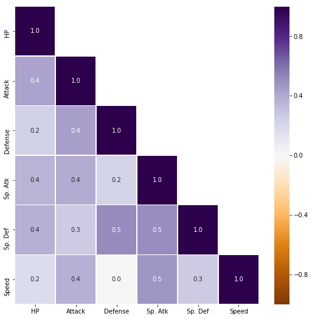

```python
f,ax = plt.subplots(figsize=(9, 9)) #Control size of the heatmap.

## Since the correlation matrix is symmetrical, half of it is redundant.
# Let's preserve only the lower triangular with:

df_lt = corr_sub.where(np.tril(np.ones(corr_sub.shape)).astype(np.bool))
# for the upper triangular use np.triu()

sns.heatmap(df_lt,
            annot=True,
            linewidths=.5,#add a line to separate squares
            fmt= '.1f',
            vmin=-1, vmax=1,#Force color palette to -1 and 1
            center=0,
            cmap="PuOr", #Color-blind friendly palette
            #cmap="PRGn_r", #Palette reversed
            ax=ax)
plt.show()
```

Ignoring the diagonal we can see that, overall, the highest value of correlation is 0.5. A quick glance at this image can tell us that, in general, we can't predict the *defense* of a pokemon by its *speed* (or viceversa). Or that there might be a relationship between *attack* and *health* but not much.

Let's take a more in-depth look at how the different *phenotypes* of the pokemon are distributed.

```python
# melted = pd.melt(frame=pokemonData,id_vars = 'Name',
#                  value_vars= list(pokemonData.columns[2:]))
# melted.head()
```

```python
# pivoted = melted.pivot(index = 'Name', columns = 'variable',values='value')
# pivoted.head()
```

Visualization of different partitions of the data might help us notice some features about it that might not be apparent by just looking at the numbers:

Here I will create boxplots to look at how HP is disitributed across different Pokemon types (Type I) and by Generation.

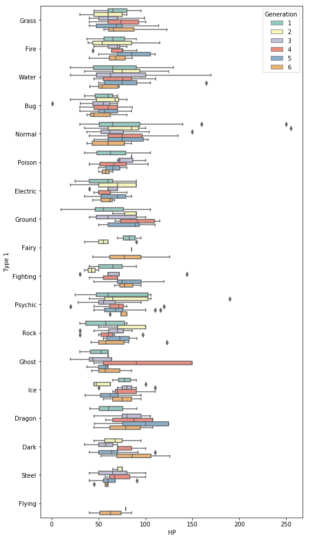

```python
plt.figure(figsize=(8, 16))
sns.boxplot(y="Type 1", x ="HP",
            hue="Generation",
            palette=sns.color_palette("Set3", 6),
            data=pokemonData)
```

Looking at the distribution of *Health Points* of different Pokemon types across generations we can learn a lot about the data. See the bottom box plot? It would appear as if *Flying* pokemon type are only in generations 5 and 6. The 5th generation of flying pokemon is easy to miss, a single bar next to the orange 6th generation.

If we filter the data we can see why:

```python
pokemonData[pokemonData["Type 1"] == "Flying"]
```

|  | # | Name | Type 1 | Type 2 | HP | Attack | Defense | Sp. Atk | Sp. Def | Speed | Generation | Legendary |
| --- | --- | --- | --- | --- | --- | --- | --- | --- | --- | --- | --- | --- |
| 702 | 703 | Tornadus Incarnate Forme | Flying | NaN | 79 | 115 | 70 | 125 | 80 | 111 | 5 | True |
| 703 | 704 | Tornadus Therian Forme | Flying | NaN | 79 | 100 | 80 | 110 | 90 | 121 | 5 | True |
| 790 | 791 | Noibat | Flying | Dragon | 40 | 30 | 35 | 45 | 40 | 55 | 6 | False |
| 791 | 792 | Noivern | Flying | Dragon | 85 | 70 | 80 | 97 | 80 | 123 | 6 | False |

As I mentioned before, data science is very much about research, and knowing about our dataset:

Trivia from the bulbapedia

> Flying was the last Pokémon type to receive:
> - A single-typed Pokémon, only receiving one with Tornadus in Generation V.
> - A dual-typed Pokémon with its type as the primary type, receiving two with Noibat and Noivern in Generation VI.

At this stage it is early to make claims about the overall data but we can see some interesting things, like the *Flying* type detail above.

For now, it looks as if *Ghost* type pokemon of the 4th generation have more *HP* than the average pokemon. *Dragon* types from 3rd gen onwards also appear to have higher HP.

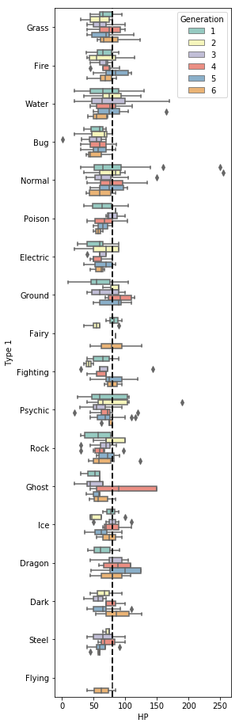

```python
plt.figure(figsize=(4, 16))
sns.boxplot(y="Type 1", x="HP",
            hue="Generation",
            palette=sns.color_palette("Set3", 6),
            data=pokemonData)
plt.axvline(pokemonData.Attack.mean(),ls='--',color="k",lw=2)
#plt.axvline(data.HP.median(),ls='dashdot',color="red",lw=2) #For the median
```

Which Pokemon are *harder, better faster stronger*<sup>[.](https://www.youtube.com/watch?v=gAjR4_CbPpQ)</sup>?**

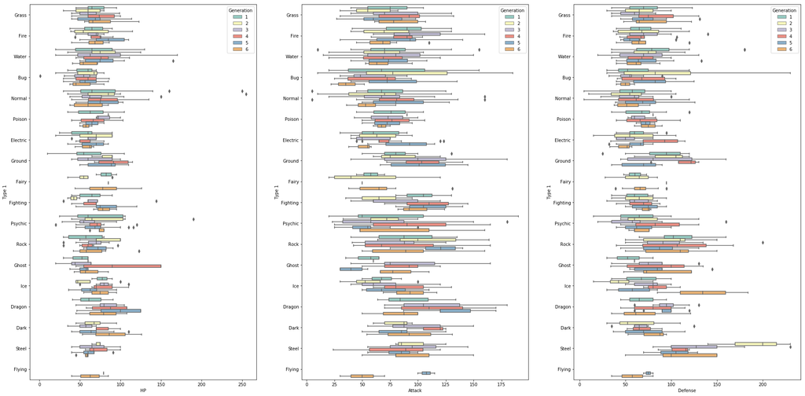

```python
#todo: figure out how to add the vertical lines to each subplot. Current code adds all lines to the last plot...miss you ggplot2() :`(

#plt.figure(figsize=)
#f,ax = plt.subplots(figsize=(9, 9))
#fig, axes = plt.subplots(nrows=1,ncols=3,figsize=(8, 16))
f, axes = plt.subplots(1, 3,figsize=(32, 16))
sns.boxplot(y="Type 1", x="HP",
            hue="Generation", ax=axes[0],
            palette=sns.color_palette("Set3", 6),
            data=pokemonData)
#plt.axvline(pokemonData.HP.mean(),ls='--',color="k",lw=2)
sns.boxplot(y="Type 1", x="Attack",
            hue="Generation", ax=axes[1],
            palette=sns.color_palette("Set3", 6),
            data=pokemonData)
#plt.axvline(pokemonData.Attack.mean(),ls='--',color="k",lw=2)

sns.boxplot(y="Type 1", x="Defense",
            hue="Generation", ax=axes[2],
            palette=sns.color_palette("Set3", 6),
            data=pokemonData)
#plt.axvline(pokemonData.Defense.mean(),ls='--',color="k",lw=2)
```

```python
# Average HP, Attack and Defense points:

print(pokemonData.HP.mean())
print(pokemonData.Attack.mean())
print(pokemonData.Defense.mean())
```

```
69.25875
79.00125
73.8425
```

It would appear as if *Defense* in *Dragon* types is somewhat around the average, but their *Attack* and *HP* are somewheat above average...

To answer this question we could get divide the HP, Attack and Defense values for the grand mean of each and see how the distribution changes. Values close to **1** are close to the mean. Values that are (way) smaller than 1, are far below the mean. Higher values are way above the mean.

We could keep plotting all day long, trying new ways to look at the data but it would take more time and we still have more datasets to look at!

## Combats dataset

This dataset contains information about 50,000 fights between pokemon (first and second columns). The third column states the winner.

An important detail is that the pokemon in the **first column attacks first**.

Also, we only have the ID's not the names (relational data, yay!! *spoiler alert*)

```python
# First, read the data and take a peek at it:
combatsData = pd.read_csv('data/combats.csv')
```

```python
combatsData.shape
```

```
(50000, 3)
```

```python
combatsData.head()
```

|  | First_pokemon | Second_pokemon | Winner |
| --- | --- | --- | --- |
| 0 | 266 | 298 | 298 |
| 1 | 702 | 701 | 701 |
| 2 | 191 | 668 | 668 |
| 3 | 237 | 683 | 683 |
| 4 | 151 | 231 | 151 |

The first question that came to my mind was...are there any instances of a pokemon fighting "itself"?

```python
(combatsData.First_pokemon == combatsData.Second_pokemon).describe()
```

```
count     50000
unique        1
top       False
freq      50000
dtype: object
```

Nope, there is no data about a Pokemon fighting itself...would that be an even fight?

[figure not shown]

Same as before, test for missing values.

```python
pd.isna(combatsData).sum()
```

```
First_pokemon     0
Second_pokemon    0
Winner            0
dtype: int64
```

Which pokemon has the most wins?

```python
# Bring in a new tool
from collections import Counter
```

```python
FreqWins = Counter(combatsData.Winner)
```

The top 5 winners are:

```python
top5 = FreqWins.most_common(5)
top5 = pd.DataFrame(top5,columns=["#","Wins"])
```

|  | # | Wins |
| --- | --- | --- |
| 0 | 163 | 152 |
| 1 | 154 | 136 |
| 2 | 438 | 136 |
| 3 | 428 | 134 |
| 4 | 314 | 133 |

Who are these Pokemon?

```python
# Use pandas and merge to work with relational data:

top5_pokemon=pd.merge(left=top5,right=pokemonData,
         left_on='#', right_on=['#'],how="inner")
```

|  | # | Wins | Name | Type 1 | Type 2 | HP | Attack | Defense | Sp. Atk | Sp. Def | Speed | Generation | Legendary |
| --- | --- | --- | --- | --- | --- | --- | --- | --- | --- | --- | --- | --- | --- |
| 0 | 163 | 152 | Mewtwo | Psychic | NaN | 106 | 110 | 90 | 154 | 90 | 130 | 1 | True |
| 1 | 154 | 136 | Aerodactyl | Rock | Flying | 80 | 105 | 65 | 60 | 75 | 130 | 1 | False |
| 2 | 438 | 136 | Infernape | Fire | Fighting | 76 | 104 | 71 | 104 | 71 | 108 | 4 | False |
| 3 | 428 | 134 | Jirachi | Steel | Psychic | 100 | 100 | 100 | 100 | 100 | 100 | 3 | True |
| 4 | 314 | 133 | Slaking | Normal | NaN | 150 | 160 | 100 | 95 | 65 | 100 | 3 | False |

Metwo had the most wins overall

[figure not shown]

A more in-depth question we can ask is, what are the win frequencies of these pokemon's according to their attack position?

```python
## Let's count how many fights each pokemon had a first or second fighter and their total.
# Using dictionaries will make our lifes easier.
FirstFreq=Counter(combatsData.First_pokemon)
SecondFreq=Counter(combatsData.Second_pokemon)
totalCombats= FirstFreq + SecondFreq
```

```python
from collections import OrderedDict as OrderedDict
FrequencyCombats = pd.DataFrame([FirstFreq,
                                SecondFreq,
                                totalCombats,
                                FreqWins], # FreqWins was calculated at an earlier step
                                index=['FirstFightFreq',
                                       'SecondFightFreq',
                                       "TotalFights",
                                       "WinsFreq"]).T

#FrequencyCombats = pd.DataFrame.from_dict(OrderedDict(zip(['foo', 'bar'], [FirstFreq, SecondFreq])))
```

|  | FirstFightFreq | SecondFightFreq | TotalFights | WinsFreq |
| --- | --- | --- | --- | --- |
| 1 | 70.0 | 63.0 | 133.0 | 37.0 |
| 2 | 55.0 | 66.0 | 121.0 | 46.0 |
| 3 | 68.0 | 64.0 | 132.0 | 89.0 |
| 4 | 62.0 | 63.0 | 125.0 | 70.0 |
| 5 | 50.0 | 62.0 | 112.0 | 55.0 |

A good practice when working with large datasets is to check if what we are doing is correct. Can we really trust that when converting a list of dictionaries to a DataFrame everything was in the same order? Let's double check that:

```python
# Check if order is preserved
print(FirstFreq[163])
print(SecondFreq[163])
print(totalCombats[163])
print(FreqWins[163])
#
print(FrequencyCombats.loc[163]) #Use .loc[PokemonID]
```

```
90
74
164
152
FirstFightFreq      90.0
SecondFightFreq     74.0
TotalFights        164.0
WinsFreq           152.0
Name: 163, dtype: float64
```

Ok, test passed, moving on.

Now let's add some information to the data:

```python
### Add pokemon names to the data
FrequencyCombats["#"]=FrequencyCombats.index
FrequencyCombats.head()
FrequencyCombats=pd.merge(left=FrequencyCombats,right=pokemonData.loc[:,["#","Name"]],
         left_on='#', right_on=['#'],how="outer")

# Fix the index, merging messes something up
FrequencyCombats=FrequencyCombats.set_index("#",drop=False)
```

I calculated some simple summaries for this data. For each pokemon, I now have the number of times (frequency) it fought first or second, wins and win ratios.

| # | FirstFightFreq | SecondFightFreq | TotalFights | WinsFreq | # | Name |
| --- | --- | --- | --- | --- | --- | --- |
| 1 | 70.0 | 63.0 | 133.0 | 37.0 | 1 | Bulbasaur |
| 2 | 55.0 | 66.0 | 121.0 | 46.0 | 2 | Ivysaur |
| 3 | 68.0 | 64.0 | 132.0 | 89.0 | 3 | Venusaur |
| 4 | 62.0 | 63.0 | 125.0 | 70.0 | 4 | Mega Venusaur |
| 5 | 50.0 | 62.0 | 112.0 | 55.0 | 5 | Charmander |

#### the art of war

> The person who throws the first punch wins a fight 90% of the time. It gives you the advantage in the fight.

Does it really? To do this we need to go back and partition the frequency of wins when it fought first or second.

Here I'm going to test a different approach and later go back to counting by position to see if this approach is good enough. I am "correcting" the fraction of wins by the quotient of $\frac{Second}{First}$. If a fighter fought more frequently as second, the quotient will be $\gt{1}$ and inflate the wins fraction.

```python
FrequencyCombats["WinFraction"]=FrequencyCombats.WinsFreq/FrequencyCombats.TotalFights
```

```python
FrequencyCombats["weightedWinFraction"]=FrequencyCombats.WinFraction*FrequencyCombats.SecondFightFreq/FrequencyCombats.FirstFightFreq
```

| # | FirstFightFreq | SecondFightFreq | TotalFights | WinsFreq | # | Name | WinFraction | weightedWinFraction |
| --- | --- | --- | --- | --- | --- | --- | --- | --- |
| 1 | 70.0 | 63.0 | 133.0 | 37.0 | 1 | Bulbasaur | 0.278195 | 0.250376 |
| 2 | 55.0 | 66.0 | 121.0 | 46.0 | 2 | Ivysaur | 0.380165 | 0.456198 |
| 3 | 68.0 | 64.0 | 132.0 | 89.0 | 3 | Venusaur | 0.674242 | 0.634581 |
| 4 | 62.0 | 63.0 | 125.0 | 70.0 | 4 | Mega Venusaur | 0.560000 | 0.569032 |
| 5 | 50.0 | 62.0 | 112.0 | 55.0 | 5 | Charmander | 0.491071 | 0.608929 |

Let's take a look at our winner. Overall, Mewtwo had the most wins, but in 90 out of 164 fights it fought first. Mewtwo won ~92% of the fights, but if we account for the starting position, the proportion goes to ~76%:

| # | FirstFightFreq | SecondFightFreq | TotalFights | WinsFreq | # | Name | WinFraction | weightedWinFraction |
| --- | --- | --- | --- | --- | --- | --- | --- | --- |
| 163 | 90.0 | 74.0 | 164.0 | 152.0 | 163 | Mewtwo | 0.926829 | 0.76206 |

Let's look at Aerodactyl. Its corrected fraction actually goes up. Does it mean that Aerodactyl tends to win more fights when it starts second? We can't really say that since we have more data for it as a second fighter.

| # | FirstFightFreq | SecondFightFreq | TotalFights | WinsFreq | # | Name | WinFraction | weightedWinFraction |
| --- | --- | --- | --- | --- | --- | --- | --- | --- |
| 154 | 65.0 | 76.0 | 141.0 | 136.0 | 154 | Aerodactyl | 0.964539 | 1.127769 |

Which pokemon has the highest proportion of wins when accounting for position?

```python
FrequencyCombats.loc[[FrequencyCombats["weightedWinFraction"].idxmax(axis=2, skipna=True)]]
```

| # | FirstFightFreq | SecondFightFreq | TotalFights | WinsFreq | # | Name | WinFraction | weightedWinFraction |
| --- | --- | --- | --- | --- | --- | --- | --- | --- |
| 714 | 41.0 | 75.0 | 116.0 | 100.0 | 714 | Keldeo Ordinary Forme | 0.862069 | 1.576955 |

And the top 5?

```python
FrequencyCombats.loc[FrequencyCombats.weightedWinFraction.nlargest(5).index]
```

| # | FirstFightFreq | SecondFightFreq | TotalFights | WinsFreq | # | Name | WinFraction | weightedWinFraction |
| --- | --- | --- | --- | --- | --- | --- | --- | --- |
| 714 | 41.0 | 75.0 | 116.0 | 100.0 | 714 | Keldeo Ordinary Forme | 0.862069 | 1.576955 |
| 276 | 50.0 | 76.0 | 126.0 | 119.0 | 276 | Mega Sceptile | 0.944444 | 1.435556 |
| 234 | 45.0 | 68.0 | 113.0 | 106.0 | 234 | Sneasel | 0.938053 | 1.417502 |
| 350 | 50.0 | 70.0 | 120.0 | 114.0 | 350 | Mega Sharpedo | 0.950000 | 1.330000 |
| 394 | 59.0 | 80.0 | 139.0 | 130.0 | 394 | Mega Absol | 0.935252 | 1.268138 |

```python
pokemonData.iloc[FrequencyCombats.weightedWinFraction.nlargest(5).index-1] #Fix: -1 bc of 0 indexing
```

|  | # | Name | Type 1 | Type 2 | HP | Attack | Defense | Sp. Atk | Sp. Def | Speed | Generation | Legendary |
| --- | --- | --- | --- | --- | --- | --- | --- | --- | --- | --- | --- | --- |
| 713 | 714 | Keldeo Ordinary Forme | Water | Fighting | 91 | 72 | 90 | 129 | 90 | 108 | 5 | False |
| 275 | 276 | Mega Sceptile | Grass | Dragon | 70 | 110 | 75 | 145 | 85 | 145 | 3 | False |
| 233 | 234 | Sneasel | Dark | Ice | 55 | 95 | 55 | 35 | 75 | 115 | 2 | False |
| 349 | 350 | Mega Sharpedo | Water | Dark | 70 | 140 | 70 | 110 | 65 | 105 | 3 | False |
| 393 | 394 | Mega Absol | Dark | NaN | 65 | 150 | 60 | 115 | 60 | 115 | 3 | False |

But...is it true? These are weighted fractions for Pokemon who had had more fights starting as second. Let's check the winning frequencies by staring position.

As a wise man said:

[figure not shown]

### Partition wins by starting position

Let's continue the traddition of split, apply combine.

The idea will be to now group oour combats data

|  | First_pokemon | Second_pokemon | Winner |
| --- | --- | --- | --- |
| 0 | 266 | 298 | 298 |
| 1 | 702 | 701 | 701 |
| 2 | 191 | 668 | 668 |
| 3 | 237 | 683 | 683 |
| 4 | 151 | 231 | 151 |

by either *First* or *Second* and then count the number of wins for each...easy, right?

**1** - Group by the pokemon that fought first and count the frequency of wins for each combination

```python
FirstWinsFreq=combatsData.groupby("First_pokemon")['Winner'].value_counts().to_frame()
FirstWinsFreq.head()
```

| First_pokemon | Winner | Winner |
| --- | --- | --- |
| 1 | 1 | 12 |
|  | 75 | 2 |
|  | 533 | 2 |
|  | 687 | 2 |
|  | 6 | 1 |

**2** - The `.to_frame()` method converts the `Series` to a data frame, however we now have a multi-level index (think `rows`). And a `Winner` column. This last column is not the actual winner but the frequency.

```python
FirstWinsFreq.rename(columns = {'Winner':'FirstWinsFreq'}, inplace = True)
```

**3** - Now, convert the multilevel index to columns to make it easier to filter out the frequency in which a Pokemon that started first actually won

```python
FirstWinsFreq.reset_index(inplace=True)
```

**4** - Check the result

```python
FirstWinsFreq.head()
```

|  | First_pokemon | Winner | FirstWinsFreq |
| --- | --- | --- | --- |
| 0 | 1 | 1 | 12 |
| 1 | 1 | 75 | 2 |
| 2 | 1 | 533 | 2 |
| 3 | 1 | 687 | 2 |
| 4 | 1 | 6 | 1 |

**5** - Filter again. The table above represents the total wins (third column) of a pokemon who fought first (left column) as a function of who won that fight (second column). Since we want to know the frequency in which a Pokemon won, we have to look for instances in which the first and second columns are the same:

```python
FirstWinsFreq=FirstWinsFreq[FirstWinsFreq.First_pokemon == FirstWinsFreq.Winner].iloc[:,[0,2]]
```

```python
FirstWinsFreq=FirstWinsFreq[FirstWinsFreq.First_pokemon == FirstWinsFreq.Winner].iloc[:,[0,2]]
```

Now we have the number of times a pokemon won when it started first:

```python
FirstWinsFreq.head()
```

|  | First_pokemon | FirstWinsFreq |
| --- | --- | --- |
| 0 | 1 | 12 |
| 56 | 2 | 20 |
| 91 | 3 | 43 |
| 116 | 4 | 36 |
| 143 | 5 | 24 |

```python
FirstWinsFreq[FirstWinsFreq.First_pokemon == 163] # Mewtwo should be 81 times
```

|  | First_pokemon | FirstWinsFreq |
| --- | --- | --- |
| 5131 | 163 | 81 |

**6** Rinse and repeat:

```python
SecondWinsFreq=combatsData.groupby("Second_pokemon")['Winner'].value_counts().to_frame()
SecondWinsFreq.rename(columns = {'Winner':'SecondWinsFreq'}, inplace = True)
SecondWinsFreq.reset_index(inplace=True)
SecondWinsFreq=SecondWinsFreq[SecondWinsFreq.Second_pokemon == SecondWinsFreq.Winner].iloc[:,[0,2]]
SecondWinsFreq.head()
```

|  | Second_pokemon | SecondWinsFreq |
| --- | --- | --- |
| 0 | 1 | 25 |
| 38 | 2 | 26 |
| 78 | 3 | 46 |
| 97 | 4 | 34 |
| 125 | 5 | 31 |

```python
SecondWinsFreq[SecondWinsFreq.Second_pokemon==163]
```

|  | Second_pokemon | SecondWinsFreq |
| --- | --- | --- |
| 4558 | 163 | 71 |

```python
combatsData[combatsData.Second_pokemon==163].groupby("Second_pokemon")['Winner'].value_counts()
```

```
Second_pokemon  Winner
163             163       71
                432        1
                686        1
                696        1
Name: Winner, dtype: int64
```

```python
FrequencyCombats_updated = pd.merge(left=FrequencyCombats,right=FirstWinsFreq,
         left_on='#', right_on=['First_pokemon'],how="outer").drop(columns='First_pokemon')
```

```python
FrequencyCombats_updated = pd.merge(left=FrequencyCombats_updated,right=SecondWinsFreq,
         left_on='#', right_on=['Second_pokemon'],how="outer").drop(columns='Second_pokemon')
```

```python
FrequencyCombats_updated.head()
```

|  | FirstFightFreq | SecondFightFreq | TotalFights | WinsFreq | # | Name | WinFraction | weightedWinFraction | FirstWinsFreq | SecondWinsFreq |
| --- | --- | --- | --- | --- | --- | --- | --- | --- | --- | --- |
| 0 | 70.0 | 63.0 | 133.0 | 37.0 | 1 | Bulbasaur | 0.278195 | 0.250376 | 12.0 | 25.0 |
| 1 | 55.0 | 66.0 | 121.0 | 46.0 | 2 | Ivysaur | 0.380165 | 0.456198 | 20.0 | 26.0 |
| 2 | 68.0 | 64.0 | 132.0 | 89.0 | 3 | Venusaur | 0.674242 | 0.634581 | 43.0 | 46.0 |
| 3 | 62.0 | 63.0 | 125.0 | 70.0 | 4 | Mega Venusaur | 0.560000 | 0.569032 | 36.0 | 34.0 |
| 4 | 50.0 | 62.0 | 112.0 | 55.0 | 5 | Charmander | 0.491071 | 0.608929 | 24.0 | 31.0 |

I used an "outer" join for the merge to account pokemon that didn't win. We don't have data about how Blastoise did, since it never fought:

|  | First_pokemon | Second_pokemon | Winner | WinnerCode |
| --- | --- | --- | --- | --- |

We therefore have an empty table.

We now calculate the frequency of wins according to starting position:

```python
FrequencyCombats_updated["SecondWinsRatio"]=FrequencyCombats_updated.SecondWinsFreq/FrequencyCombats_updated.SecondFightFreq
FrequencyCombats_updated["FirstWinsRatio"]=FrequencyCombats_updated.FirstWinsFreq/FrequencyCombats_updated.FirstFightFreq
```

```python
FrequencyCombats_updated.head()
```

|  | FirstFightFreq | SecondFightFreq | TotalFights | WinsFreq | # | Name | WinFraction | weightedWinFraction | FirstWinsFreq | SecondWinsFreq | SecondWinsRatio | FirstWinsRatio |
| --- | --- | --- | --- | --- | --- | --- | --- | --- | --- | --- | --- | --- |
| 0 | 70.0 | 63.0 | 133.0 | 37.0 | 1 | Bulbasaur | 0.278195 | 0.250376 | 12.0 | 25.0 | 0.396825 | 0.171429 |
| 1 | 55.0 | 66.0 | 121.0 | 46.0 | 2 | Ivysaur | 0.380165 | 0.456198 | 20.0 | 26.0 | 0.393939 | 0.363636 |
| 2 | 68.0 | 64.0 | 132.0 | 89.0 | 3 | Venusaur | 0.674242 | 0.634581 | 43.0 | 46.0 | 0.718750 | 0.632353 |
| 3 | 62.0 | 63.0 | 125.0 | 70.0 | 4 | Mega Venusaur | 0.560000 | 0.569032 | 36.0 | 34.0 | 0.539683 | 0.580645 |
| 4 | 50.0 | 62.0 | 112.0 | 55.0 | 5 | Charmander | 0.491071 | 0.608929 | 24.0 | 31.0 | 0.500000 | 0.480000 |

Finally, change any NA value to 0

```python
FrequencyCombats_updated = FrequencyCombats_updated.fillna(0)
FrequencyCombats_updated[FrequencyCombats_updated["#"] == 266]
```

|  | FirstFightFreq | SecondFightFreq | TotalFights | WinsFreq | # | Name | WinFraction | weightedWinFraction | FirstWinsFreq | SecondWinsFreq | SecondWinsRatio | FirstWinsRatio |
| --- | --- | --- | --- | --- | --- | --- | --- | --- | --- | --- | --- | --- |
| 256 | 58.0 | 52.0 | 110.0 | 25.0 | 266 | Larvitar | 0.227273 | 0.203762 | 12.0 | 13.0 | 0.25 | 0.206897 |

Use the '*#*' ID as the index and sort by number:

```python
FrequencyCombats_updated=FrequencyCombats_updated.set_index("#",drop=False).sort_values(by=['#'])
```

Now, let's return to our question: who's a better fighter?

```python
pokemonDataUpdated=pokemonData
```

Since the Types for Pokemon are categorical, one trick we can use to convert them into numbers is to assign a numeric code to each. There are [18 different Pokemon types](https://bulbapedia.bulbagarden.net/wiki/Types) . Let's give them a numeric code that is the same for both:

(note that for Type2, we can have empty values. Let's treat those as 0 type)

```python
Type1Codes={'Grass':2,
 'Fire':3,
 'Water':4,
 'Bug':5,
 'Normal':1,
 'Poison':6,
 'Electric':7,
 'Ground':8,
 'Fairy':9,
 'Fighting':10,
 'Psychic':11,
 'Rock':12,
 'Ghost':13,
 'Ice':14,
 'Dragon':15,
 'Dark':16,
 'Steel':17,
 'Flying':18}

Type2Codes={'Poison':6,
     "NA":0,
     'Flying':18,
     'Dragon':15,
     'Ground':8,
     'Fairy':9,
     'Grass':2,
     'Fighting':10,
     'Psychic':11,
     'Steel':17,
     'Ice':14,
     'Rock':12,
     'Dark':16,
     'Water':4,
     'Electric':7,
     'Fire':3,
     'Ghost':13,
     'Bug':5,
     'Normal':1}
```

```python
pokemonData["Type 2"][pokemonData["Type 2"].isnull()]="NA"
```

```python
pokemonDataUpdated[["TypeA","TypeB","Legend"]] = pd.DataFrame({"TypeA":[Type1Codes[each] for each in pokemonData["Type 1"]],
              "TypeB":[Type2Codes[each] for each in pokemonData["Type 2"]],
              "Legend":pd.Categorical(pokemonData["Legendary"]).codes})
```

Since our models deal with numbers, converting these categorical variables to numerical codes will help us integrate these data.

|  | # | Name | Type 1 | Type 2 | HP | Attack | Defense | Sp. Atk | Sp. Def | Speed | Generation | Legendary | TypeA | TypeB | Legend |
| --- | --- | --- | --- | --- | --- | --- | --- | --- | --- | --- | --- | --- | --- | --- | --- |
| 0 | 1 | Bulbasaur | Grass | Poison | 45 | 49 | 49 | 65 | 65 | 45 | 1 | False | 2 | 6 | 0 |
| 1 | 2 | Ivysaur | Grass | Poison | 60 | 62 | 63 | 80 | 80 | 60 | 1 | False | 2 | 6 | 0 |
| 2 | 3 | Venusaur | Grass | Poison | 80 | 82 | 83 | 100 | 100 | 80 | 1 | False | 2 | 6 | 0 |
| 3 | 4 | Mega Venusaur | Grass | Poison | 80 | 100 | 123 | 122 | 120 | 80 | 1 | False | 2 | 6 | 0 |
| 4 | 5 | Charmander | Fire | NA | 39 | 52 | 43 | 60 | 50 | 65 | 1 | False | 3 | 0 | 0 |

# Predicting outcomes of fights

How can we make use of our data to predict the winner of a fight?

Essentialy what we're going to do is pass some data to a machine learning model (function), evaluate and compare against a **known** output (winner of the fight). With each observation, the model gets refined so that it will hopefull predict given a list of data who is more likely to win that fight.

What combination of data can we feed the model?

The simples idea I can think of is to just concatenate the list of values for each of the two Pokemon in a combat and evaluate the result as binary. If the first Pokemon wins the output should be 1, else is 0.

We could also pass the difference of the values: $First-Second$  
or the ratio $\frac{First}{Second}$

Let's do the simples thing first.

Separate each set of values depending on the starting position of the fight:

```python
FirstPokemon = pokemonDataUpdated.iloc[combatsData.First_pokemon-1][['HP', 'Attack', 'Defense', 'Sp. Atk','Sp. Def', 'Speed', 'Generation', 'Legend',"TypeA","TypeB"]]
SecondPokemon = pokemonDataUpdated.iloc[combatsData.Second_pokemon-1][['HP', 'Attack', 'Defense', 'Sp. Atk','Sp. Def', 'Speed', 'Generation', 'Legend',"TypeA","TypeB"]]
```

```python
FirstPokemon.head()
```

|  | HP | Attack | Defense | Sp. Atk | Sp. Def | Speed | Generation | Legend | TypeA | TypeB |
| --- | --- | --- | --- | --- | --- | --- | --- | --- | --- | --- |
| 265 | 50 | 64 | 50 | 45 | 50 | 41 | 2 | 0 | 12 | 8 |
| 701 | 91 | 90 | 72 | 90 | 129 | 108 | 5 | 1 | 2 | 10 |
| 190 | 55 | 40 | 85 | 80 | 105 | 40 | 2 | 0 | 9 | 18 |
| 236 | 40 | 40 | 40 | 70 | 40 | 20 | 2 | 0 | 3 | 0 |
| 150 | 70 | 60 | 125 | 115 | 70 | 55 | 1 | 0 | 12 | 4 |

And preprocess the data a little bit. Machine learning models work better with scaled data, between 0 and 1 (citation needed).

```python
from sklearn import preprocessing
```

```python
min_max_scaler = preprocessing.MinMaxScaler()
scaled_array = min_max_scaler.fit_transform(SecondPokemon)
Second_normalized = pd.DataFrame(scaled_array)
```

```python
min_max_scaler = preprocessing.MinMaxScaler()
scaled_array = min_max_scaler.fit_transform(FirstPokemon)
First_normalized = pd.DataFrame(scaled_array)
```

Raw data:

|  | HP | Attack | Defense | Sp. Atk | Sp. Def | Speed | Generation | Legend | TypeA | TypeB |
| --- | --- | --- | --- | --- | --- | --- | --- | --- | --- | --- |
| 265 | 50 | 64 | 50 | 45 | 50 | 41 | 2 | 0 | 12 | 8 |
| 701 | 91 | 90 | 72 | 90 | 129 | 108 | 5 | 1 | 2 | 10 |
| 190 | 55 | 40 | 85 | 80 | 105 | 40 | 2 | 0 | 9 | 18 |
| 236 | 40 | 40 | 40 | 70 | 40 | 20 | 2 | 0 | 3 | 0 |
| 150 | 70 | 60 | 125 | 115 | 70 | 55 | 1 | 0 | 12 | 4 |

Normalized values between 0 and 1:

|  | 0 | 1 | 2 | 3 | 4 | 5 | 6 | 7 | 8 | 9 |
| --- | --- | --- | --- | --- | --- | --- | --- | --- | --- | --- |
| 0 | 0.192913 | 0.318919 | 0.200000 | 0.190217 | 0.142857 | 0.205714 | 0.2 | 0.0 | 0.647059 | 0.444444 |
| 1 | 0.354331 | 0.459459 | 0.297778 | 0.434783 | 0.519048 | 0.588571 | 0.8 | 1.0 | 0.058824 | 0.555556 |
| 2 | 0.212598 | 0.189189 | 0.355556 | 0.380435 | 0.404762 | 0.200000 | 0.2 | 0.0 | 0.470588 | 1.000000 |
| 3 | 0.153543 | 0.189189 | 0.155556 | 0.326087 | 0.095238 | 0.085714 | 0.2 | 0.0 | 0.117647 | 0.000000 |
| 4 | 0.271654 | 0.297297 | 0.533333 | 0.570652 | 0.238095 | 0.285714 | 0.0 | 0.0 | 0.647059 | 0.222222 |

```python
combatsData["WinnerCode"]=pd.Categorical(combatsData["First_pokemon"]==combatsData["Winner"]).codes
```

We also converted the winner codes as binary. If the first pokemon wins, we get a 1, else 0:

|  | First_pokemon | Second_pokemon | Winner | WinnerCode |
| --- | --- | --- | --- | --- |
| 0 | 266 | 298 | 298 | 0 |
| 1 | 702 | 701 | 701 | 0 |
| 2 | 191 | 668 | 668 | 0 |
| 3 | 237 | 683 | 683 | 0 |
| 4 | 151 | 231 | 151 | 1 |
| 5 | 657 | 752 | 657 | 1 |
| 6 | 192 | 134 | 134 | 0 |
| 7 | 73 | 545 | 545 | 0 |
| 8 | 220 | 763 | 763 | 0 |
| 9 | 302 | 31 | 31 | 0 |

Now, where the magic happens:

We will create a table of the normalized data by concatenating the values for the pokemon that fought first and then second. We'll do this for each fight:

```python
ToML = pd.concat([First_normalized,Second_normalized,combatsData[["WinnerCode"]]],axis=1, sort=False)
```

We still have 50,000 rows and 21 columns:

(50000, 21)

10 for each Pokemon that comprise HP, Attack,Defense, etc, including if it's a legendary pokemon and the dummy code for its type: The last column indicates the code for the winner:

|  | 0 | 1 | 2 | 3 | 4 | 5 | 6 | 7 | 8 | 9 | ... | 1 | 2 | 3 | 4 | 5 | 6 | 7 | 8 | 9 | WinnerCode |
| --- | --- | --- | --- | --- | --- | --- | --- | --- | --- | --- | --- | --- | --- | --- | --- | --- | --- | --- | --- | --- | --- |
| 0 | 0.192913 | 0.318919 | 0.200000 | 0.190217 | 0.142857 | 0.205714 | 0.2 | 0.0 | 0.647059 | 0.444444 | ... | 0.351351 | 0.155556 | 0.271739 | 0.095238 | 0.314286 | 0.4 | 0.0 | 0.058824 | 0.888889 | 0 |
| 1 | 0.354331 | 0.459459 | 0.297778 | 0.434783 | 0.519048 | 0.588571 | 0.8 | 1.0 | 0.058824 | 0.555556 | ... | 0.670270 | 0.377778 | 0.336957 | 0.333333 | 0.588571 | 0.8 | 1.0 | 0.647059 | 0.555556 | 0 |
| 2 | 0.212598 | 0.189189 | 0.355556 | 0.380435 | 0.404762 | 0.200000 | 0.2 | 0.0 | 0.470588 | 1.000000 | ... | 0.378378 | 0.311111 | 0.625000 | 0.357143 | 0.200000 | 0.8 | 0.0 | 0.588235 | 0.000000 | 0 |
| 3 | 0.153543 | 0.189189 | 0.155556 | 0.326087 | 0.095238 | 0.085714 | 0.2 | 0.0 | 0.117647 | 0.000000 | ... | 0.621622 | 0.377778 | 0.271739 | 0.333333 | 0.245714 | 0.8 | 0.0 | 0.823529 | 0.000000 | 0 |
| 4 | 0.271654 | 0.297297 | 0.533333 | 0.570652 | 0.238095 | 0.285714 | 0.0 | 0.0 | 0.647059 | 0.222222 | ... | 0.027027 | 1.000000 | 0.000000 | 1.000000 | 0.000000 | 0.2 | 0.0 | 0.235294 | 0.666667 | 1 |

5 rows × 21 columns

```python
from sklearn.model_selection import train_test_split
```

```python
X = ToML.drop("WinnerCode", axis=1) # Our X (known data) are all 20 columns, except the winner code.
y = ToML["WinnerCode"] # This is the winner code.
```

Now we split our data: Use 80% of the 50,000 rows for training and the rest for testing.

> ASYD: **A**lways **S**plit **Y**our **D**ata

**Never ever ever use the whole data set for training**

```python
X_train, X_test, y_train, y_test = train_test_split(X, y, train_size=0.8, random_state=1)
```

Using a logistic regression results in almost 90% accuracy. This means that our model is able to predict 90% of the fights correctly.

```python
from sklearn.linear_model import LogisticRegression
logreg = LogisticRegression()
logreg.fit(X_train, y_train)
acc_log = round(logreg.score(X_test, y_test)*100, 2)
acc_log
```

```
89.02
```

A perceptron (a type of neural network) has a lower accuracy:

```python
from sklearn.linear_model import Perceptron
perceptron = Perceptron()
perceptron.fit(X_train, y_train)
acc_perceptron = round(perceptron.score(X_test, y_test) * 100, 2)
acc_perceptron
```

```
80.95
```

How about a forest? Random?

```python
from sklearn.ensemble import RandomForestClassifier
random_forest = RandomForestClassifier(n_estimators=100)
random_forest.fit(X_train, y_train)
acc_random_forest = round(random_forest.score(X_test, y_test) * 100, 2)
acc_random_forest
```

```
94.94
```

95% accuracy!!!

[figure not shown]

Can we improve the accuracy of the Random Forest model?

```python
from sklearn.ensemble import RandomForestClassifier
random_forest = RandomForestClassifier(n_estimators=500)
random_forest.fit(X_train, y_train)
acc_random_forest = round(random_forest.score(X_test, y_test) * 100, 2)
acc_random_forest
```

```
94.95
```

Just a little...but 95% accuracy is pretty good. With this we would expect that 1/20 results wouldn't be reliable. Not bad to predict a Pokemon fight.

# "Real" data

Now let's see how our model performs with data for which we don't have any information:

```python
tests = pd.read_csv('data/tests.csv')
```

```python
tests.head()
```

|  | First_pokemon | Second_pokemon |
| --- | --- | --- |
| 0 | 129 | 117 |
| 1 | 660 | 211 |
| 2 | 706 | 115 |
| 3 | 195 | 618 |
| 4 | 27 | 656 |

Same as before, we'll divide the values by first or second pokemon, scale it between 0 and 1 and then concatenate.

```python
testFirst=pokemonDataUpdated.iloc[tests['First_pokemon']-1][['HP', 'Attack', 'Defense', 'Sp. Atk','Sp. Def', 'Speed', 'Generation', 'Legend',"TypeA","TypeB"]]
testSecond=pokemonDataUpdated.iloc[tests['Second_pokemon']-1][['HP', 'Attack', 'Defense', 'Sp. Atk','Sp. Def', 'Speed', 'Generation', 'Legend',"TypeA","TypeB"]]
```

```python
min_max_scaler = preprocessing.MinMaxScaler()
scaled_array = min_max_scaler.fit_transform(testFirst)
testFirst_normalized = pd.DataFrame(scaled_array)
##
min_max_scaler = preprocessing.MinMaxScaler()
scaled_array = min_max_scaler.fit_transform(testSecond)
testSecond_normalized = pd.DataFrame(scaled_array)
```

```python
testPhenotype = pd.concat([testFirst_normalized,testSecond_normalized],axis=1, sort=False)
```

```python
testPhenotype.shape
```

```
(10000, 20)
```

We now predict the results with our trained Random Forest model :

```python
y_predict = random_forest.predict(testPhenotype)
y_predict = list(y_predict)
```

And check our results:

[1, 0, 1, 0, 1, 1, 1, 0, 1, 1]

Hmm...remember, we trained our model to output 1 if (according to the observed training data) the starting Pokemon was more likely to win over the second one. We now have to do some coding to convert these binary values into more friendly result:

```python
chickenDinner=[tests["First_pokemon"][each] if y_predict[each]==1 else tests["Second_pokemon"][each] for each in range(len(y_predict))]
```

```python
predictedWinners=pd.DataFrame({"First":tests["First_pokemon"],
            "Second":tests["Second_pokemon"],
            "Winner":chickenDinner})
```

|  | First | Second | Winner |
| --- | --- | --- | --- |
| 0 | 129 | 117 | 129 |
| 1 | 660 | 211 | 211 |
| 2 | 706 | 115 | 706 |
| 3 | 195 | 618 | 618 |
| 4 | 27 | 656 | 27 |
| 5 | 126 | 222 | 126 |
| 6 | 436 | 207 | 436 |
| 7 | 121 | 36 | 36 |
| 8 | 169 | 636 | 169 |
| 9 | 302 | 688 | 302 |
| 10 | 39 | 380 | 380 |
| 11 | 11 | 292 | 11 |
| 12 | 228 | 747 | 747 |
| 13 | 302 | 763 | 302 |
| 14 | 455 | 436 | 436 |

Now we are testing our predictions with data that our model has never seen and for which we don't really have any information. Does it make sense?

The first battle is Seaking vs Lickitung. Both are 1st gen pokemon, and although Seaking has lower HP, it has a stronger Attack and Speed. They are almost comparable in Defense and special defence and attack points. When we look at their records of winnings, Seaking has a greater win record (~48% of the fights won). It also wins ~50% of the fights when he starts, compared to a ~10% of Lickitung.

With these data the model chose Seaking as the winner for that fight.

|  | # | Name | Type 1 | Type 2 | HP | Attack | Defense | Sp. Atk | Sp. Def | Speed | Generation | Legendary | TypeA | TypeB | Legend |
| --- | --- | --- | --- | --- | --- | --- | --- | --- | --- | --- | --- | --- | --- | --- | --- |
| 128 | 129 | Seaking | Water | NA | 80 | 92 | 65 | 65 | 80 | 68 | 1 | False | 4 | 0 | 0 |
| 116 | 117 | Lickitung | Normal | NA | 90 | 55 | 75 | 60 | 75 | 30 | 1 | False | 1 | 0 | 0 |

| # | FirstFightFreq | SecondFightFreq | TotalFights | WinsFreq | # | Name | WinFraction | weightedWinFraction | FirstWinsFreq | SecondWinsFreq | SecondWinsRatio | FirstWinsRatio |
| --- | --- | --- | --- | --- | --- | --- | --- | --- | --- | --- | --- | --- |
| 129 | 61.0 | 53.0 | 114.0 | 55.0 | 129 | Seaking | 0.482456 | 0.419183 | 31.0 | 24.0 | 0.452830 | 0.508197 |
| 117 | 61.0 | 75.0 | 136.0 | 19.0 | 117 | Lickitung | 0.139706 | 0.171770 | 6.0 | 13.0 | 0.173333 | 0.098361 |

Going back a bit, we did not have any information about how Mega Blastoise would do in a fight:

|  | First_pokemon | Second_pokemon | Winner | WinnerCode |
| --- | --- | --- | --- | --- |

But we know its stats:

|  | # | Name | Type 1 | Type 2 | HP | Attack | Defense | Sp. Atk | Sp. Def | Speed | Generation | Legendary | TypeA | TypeB | Legend |
| --- | --- | --- | --- | --- | --- | --- | --- | --- | --- | --- | --- | --- | --- | --- | --- |
| 12 | 13 | Mega Blastoise | Water | NA | 79 | 103 | 120 | 135 | 115 | 78 | 1 | False | 4 | 0 | 0 |

From our test data, let's look for instances of Mega Blastoise fighting:

`predictedWinners[(predictedWinners.First==12) | (predictedWinners.Second==12)]`

|  | First | Second | Winner |
| --- | --- | --- | --- |
| 725 | 484 | 12 | 484 |
| 749 | 748 | 12 | 748 |
| 759 | 12 | 553 | 553 |
| 1213 | 12 | 706 | 706 |
| 2126 | 550 | 12 | 550 |
| 2234 | 412 | 12 | 12 |
| 3246 | 12 | 346 | 12 |
| 3301 | 12 | 733 | 12 |
| 3466 | 12 | 749 | 749 |
| 3492 | 12 | 648 | 648 |
| 5780 | 12 | 706 | 706 |
| 6236 | 12 | 650 | 12 |
| 6346 | 12 | 4 | 4 |
| 6799 | 12 | 139 | 139 |
| 6824 | 12 | 799 | 799 |

Let's look at some winning examples:

|  | # | Name | Type 1 | Type 2 | HP | Attack | Defense | Sp. Atk | Sp. Def | Speed | Generation | Legendary | TypeA | TypeB | Legend |
| --- | --- | --- | --- | --- | --- | --- | --- | --- | --- | --- | --- | --- | --- | --- | --- |
| 12 | 13 | Mega Blastoise | Water | NA | 79 | 103 | 120 | 135 | 115 | 78 | 1 | False | 4 | 0 | 0 |
| 346 | 347 | Swalot | Poison | NA | 100 | 73 | 83 | 73 | 83 | 55 | 3 | False | 6 | 0 | 0 |
| 733 | 734 | Spewpa | Bug | NA | 45 | 22 | 60 | 27 | 30 | 29 | 6 | False | 5 | 0 | 0 |
| 412 | 413 | Metagross | Steel | Psychic | 80 | 135 | 130 | 95 | 90 | 70 | 3 | False | 17 | 11 | 0 |
| 650 | 651 | Escavalier | Bug | Steel | 70 | 135 | 105 | 60 | 105 | 20 | 5 | False | 5 | 17 | 0 |

An interesting case is Blastoise winning as a second fighter:

|  | First | Second | Winner |
| --- | --- | --- | --- |
| 2234 | 412 | 12 | 12 |

For the other fights it looks like being first was better for M. Blastoise, while also MB has higher special A/D points.